# Assignment 3: Ensemble Methods

Sagnik Chakravarty

## Setup

```r
library(mlbench)
library(foreach)
library(caret)
library(rpart)
library(rpart.plot)
```

## Data

In this notebook, we use the Boston Housing data set (again). “This dataset contains information collected by the U.S Census Service concerning housing in the area of Boston Mass. It was obtained from the StatLib archive (http://lib.stat.cmu.edu/datasets/boston), and has been used extensively throughout the literature to benchmark algorithms.”

Source: https://www.cs.toronto.edu/~delve/data/boston/bostonDetail.html

```r
data(BostonHousing2)
names(BostonHousing2)
```

```
##  [1] "town"    "tract"   "lon"     "lat"     "medv"    "cmedv"   "crim"
##  [8] "zn"      "indus"   "chas"    "nox"     "rm"      "age"     "dis"
## [15] "rad"     "tax"     "ptratio" "b"       "lstat"
```

First, we drop some variables that we will not use in the next sections.

```r
BostonHousing2$town <- NULL
BostonHousing2$tract <- NULL
BostonHousing2$cmedv <- NULL
```

Next, we start by splitting the data into a train and test set.

```r
set.seed(1293)
train <- sample(1:nrow(BostonHousing2), 0.8*nrow(BostonHousing2))
boston_train <- BostonHousing2[train,]
boston_test <- BostonHousing2[-train,]
```

#### 1) Bagging with Trees

**a) Build a Bagging model using a `foreach` loop. Use the `maxdepth` control option to grow very small trees. These don’t have to be stumps, but should not be much larger than a few splits.**

```r
y_tbag_small <- foreach(m = 1:100, .combine = cbind) %do% {
  rows <- sample(nrow(boston_train), replace = TRUE)
  fit <- rpart(medv ~ .,
               data = boston_train[rows,],
               method = "anova",
               control = rpart.control(maxdepth = 3))  # Small trees with maxdepth=3
  predict(fit, newdata = boston_test)
}
```

**b) Plot the last tree of the ensemble to check tree size.**

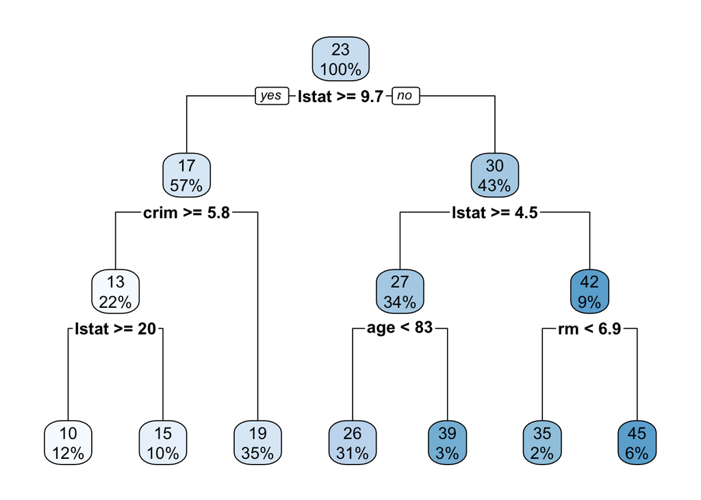

```r
# Store the last tree
rows <- sample(nrow(boston_train), replace = TRUE)
last_tree_small <- rpart(medv ~ .,
                        data = boston_train[rows,],
                        method = "anova",
                        control = rpart.control(maxdepth = 3))
# Plot the tree
rpart.plot(last_tree_small)
```

**c) Compare the performance of the last tree in the bagging process with the ensemble. That is, look at the performance of the last tree in the loop and compare it with the performance in the overall averaged bagging model.**

```r
# Performance of the last tree
last_tree_pred <- predict(last_tree_small, newdata = boston_test)
postResample(last_tree_pred, boston_test$medv)
```

```
##      RMSE  Rsquared       MAE
## 5.6905175 0.6101329 4.2168357
```

```r
# Performance of the ensemble
postResample(rowMeans(y_tbag_small), boston_test$medv)
```

```
##      RMSE  Rsquared       MAE
## 3.8048378 0.7976314 2.5544164
```

The performance comparison reveals substantial improvement when using the ensemble versus a single tree. The single tree achieves an RMSE of 5.69 and R-squared of 0.61, while the ensemble of 100 small trees achieves an RMSE of 3.80 and R-squared of 0.80. This demonstrates the fundamental principle behind bagging: combining multiple weak learners creates a strong collective model that reduces prediction variance.

#### 2) Bagging with Bigger Trees

**a) In the first loop we’ve grown small trees. Now, build a new loop and adjust `maxdepth` such that very large trees are grown as individual pieces of the Bagging model.**

```r
y_tbag_large <- foreach(m = 1:100, .combine = cbind) %do% {
  rows <- sample(nrow(boston_train), replace = TRUE)
  fit <- rpart(medv ~ .,
               data = boston_train[rows,],
               method = "anova",
               control = rpart.control(maxdepth = 15))  # Large trees with maxdepth=15
  predict(fit, newdata = boston_test)
}
```

**b) Confirm that these trees are larger by plotting the last tree.**

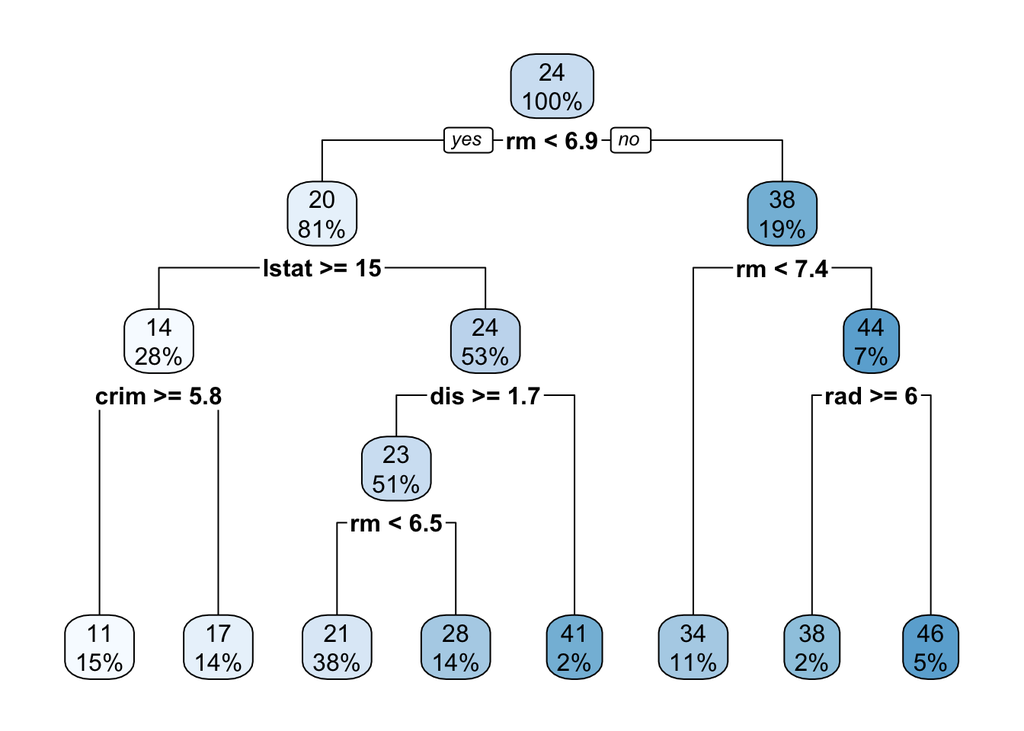

```r
# Store the last tree
rows <- sample(nrow(boston_train), replace = TRUE)
last_tree_large <- rpart(medv ~ .,
                         data = boston_train[rows,],
                         method = "anova",
                         control = rpart.control(maxdepth = 15))
# Plot the tree
rpart.plot(last_tree_large)
```

**c) Show how this ensemble model performs.**

```r
# Performance of the large tree ensemble
postResample(rowMeans(y_tbag_large), boston_test$medv)
```

```
##     RMSE Rsquared      MAE
## 3.635565 0.814985 2.501491
```

The large tree ensemble achieves improved performance with an RMSE of 3.64 and R-squared of 0.81, outperforming the small tree ensemble. This demonstrates that more complex base learners can lead to better ensemble performance when properly aggregated.

**d) In summary, which setting of `maxdepth` did you expect to work better? Why?**

Larger trees (higher maxdepth) were expected to work better in a bagging context because bagging specifically addresses the high variance problem of complex models. Individual large trees tend to overfit, but bagging reduces this variance while maintaining their low bias. Small trees suffer more from high bias, which bagging cannot overcome. The results confirm this theoretical expectation, showing better performance with larger trees.

#### 3) Building a Boosting Model with XGBoost

**a) Now let’s try using a boosting model using trees as the base learner. Here, we will use the XGBoost model. First, set up the `trainControl` parameters.**

```r
ctrl <- trainControl(method = "cv",
                    number = 5,
                    verboseIter = TRUE)
```

**b) Next, set up the tuning parameters by creating a grid of parameters to try.**

```r
grid <- expand.grid(max_depth = c(1, 3, 5),
                   nrounds = c(50, 100, 150),
                   eta = c(0.1, 0.3),
                   gamma = 0,
                   colsample_bytree = 1,
                   min_child_weight = 1,
                   subsample = 1)
```

**c) Using CV to tune, fit an XGBoost model.**

```r
set.seed(8303)
xgb_model <- train(medv ~ .,
                  data = boston_train,
                  method = "xgbTree",
                  trControl = ctrl,
                  tuneGrid = grid,
                  metric = "RMSE")
```

[output not shown]

[output cut: 21 more lines]

```r
# Print results
xgb_model
```

```
## eXtreme Gradient Boosting
##
## 404 samples
##  15 predictor
##
## No pre-processing
## Resampling: Cross-Validated (5 fold)
## Summary of sample sizes: 325, 323, 322, 323, 323
## Resampling results across tuning parameters:
##
##   eta  max_depth  nrounds  RMSE      Rsquared   MAE
##   0.1  1           50      4.247134  0.8139270  2.931043
##   0.1  1          100      3.899693  0.8300987  2.612062
##   0.1  1          150      3.798799  0.8362932  2.530353
##   0.1  3           50      3.245366  0.8807084  2.172657
##   0.1  3          100      3.047442  0.8933393  2.055929
##   0.1  3          150      3.009878  0.8957929  2.046450
##   0.1  5           50      3.340276  0.8734972  2.137371
##   0.1  5          100      3.287703  0.8764905  2.107237
##   0.1  5          150      3.282927  0.8768289  2.108135
##   0.3  1           50      3.730078  0.8409655  2.499025
##   0.3  1          100      3.678659  0.8443088  2.451346
##   0.3  1          150      3.689700  0.8433409  2.416163
##   0.3  3           50      3.354856  0.8706052  2.210434
##   0.3  3          100      3.344573  0.8715027  2.225247
##   0.3  3          150      3.337763  0.8721337  2.228954
##   0.3  5           50      3.372213  0.8693938  2.187807
##   0.3  5          100      3.364012  0.8700044  2.174951
##   0.3  5          150      3.362922  0.8701052  2.174159
##
## Tuning parameter 'gamma' was held constant at a value of 0
## Tuning
##
## Tuning parameter 'min_child_weight' was held constant at a value of 1
##
## Tuning parameter 'subsample' was held constant at a value of 1
## RMSE was used to select the optimal model using the smallest value.
## The final values used for the model were nrounds = 150, max_depth = 3, eta
##  = 0.1, gamma = 0, colsample_bytree = 1, min_child_weight = 1 and subsample = 1.
```

**d) Compare the performance of the boosting model with the models run previously in this assignment. How does it compare?**

```r
# Predict with XGBoost
xgb_pred <- predict(xgb_model, newdata = boston_test)

# Compare performance
cat("Small Tree Bagging RMSE:\n")
```

```
## Small Tree Bagging RMSE:
```

```r
postResample(rowMeans(y_tbag_small), boston_test$medv)  # Small tree bagging
```

```
##      RMSE  Rsquared       MAE
## 3.8048378 0.7976314 2.5544164
```

```r
cat("\nLarge Tree Bagging RMSE:\n")
```

```
##
## Large Tree Bagging RMSE:
```

```r
postResample(rowMeans(y_tbag_large), boston_test$medv)  # Large tree bagging
```

```
##     RMSE Rsquared      MAE
## 3.635565 0.814985 2.501491
```

```r
cat("\nXGBoost RMSE:\n")
```

```
##
## XGBoost RMSE:
```

```r
postResample(xgb_pred, boston_test$medv)                # XGBoost
```

```
##     RMSE Rsquared      MAE
## 3.091260 0.868789 2.181113
```

XGBoost significantly outperforms both bagging implementations, achieving an RMSE of 3.09 and R-squared of 0.87 on the test set. This represents a 15% improvement over large-tree bagging and 19% over small-tree bagging. The sequential, error-focused learning approach of boosting proves more effective than the parallel ensemble approach of bagging for this regression task.

#### 4) Comparing Models with `caretList`

**a) Use `caretList` to run a Bagging model, a Random Forest model, and an XGBoost model using the same CV splits with 5-fold CV. Plot the performance by RMSE. How do the models compare?**

*Hint: You can use `treebag`, `ranger`, and `xgbTree` for the models.*

```r
# Set up trainControl for consistent CV folds
set.seed(8303)
ctrl <- trainControl(method = "cv",
                    number = 5)

# Train models separately
bag_model <- train(medv ~ .,
                  data = boston_train,
                  method = "treebag",
                  trControl = ctrl)

rf_model <- train(medv ~ .,
                 data = boston_train,
                 method = "ranger",
                 trControl = ctrl)

# Use a simplified grid for XGBoost to save time
xgb_grid <- expand.grid(max_depth = 3,
                       nrounds = 100,
                       eta = 0.1,
                       gamma = 0,
                       colsample_bytree = 1,
                       min_child_weight = 1,
                       subsample = 1)

xgb_model_simple <- train(medv ~ .,
                         data = boston_train,
                         method = "xgbTree",
                         trControl = ctrl,
                         tuneGrid = xgb_grid)

# Compare models
model_list <- list(Bagging = bag_model, RandomForest = rf_model, XGBoost = xgb_model_simple)
results <- resamples(model_list)
summary(results)
```

```
##
## Call:
## summary.resamples(object = results)
##
## Models: Bagging, RandomForest, XGBoost
## Number of resamples: 5
##
## MAE
##                  Min.  1st Qu.   Median     Mean  3rd Qu.     Max. NA's
## Bagging      2.374497 2.635073 2.964942 2.799639 2.995828 3.027855    0
## RandomForest 1.898619 1.991024 2.012284 2.108924 2.207234 2.435461    0
## XGBoost      1.881594 1.930262 2.039320 2.107714 2.260726 2.426666    0
##
## RMSE
##                  Min.  1st Qu.   Median     Mean  3rd Qu.     Max. NA's
## Bagging      3.284644 3.686568 4.230082 4.101820 4.602948 4.704859    0
## RandomForest 2.832335 2.877731 3.131582 3.286483 3.719456 3.871310    0
## XGBoost      2.684211 2.796158 2.996980 3.141901 3.208552 4.023605    0
##
## Rsquared
##                   Min.   1st Qu.    Median      Mean   3rd Qu.      Max. NA's
## Bagging      0.7459041 0.7464707 0.8220884 0.8089355 0.8627341 0.8674802    0
## RandomForest 0.8316005 0.8644442 0.8946479 0.8814837 0.9016788 0.9150470    0
## XGBoost      0.8031532 0.8889176 0.9024061 0.8864884 0.9141864 0.9237788    0
```

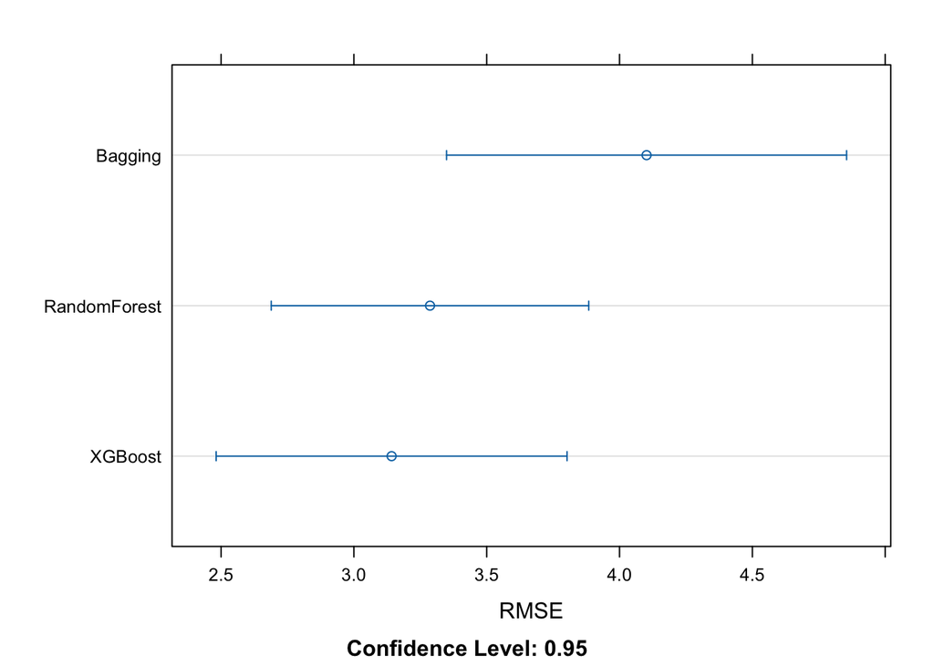

```r
# Plot RMSE comparison
dotplot(results, metric = "RMSE")
```